# Normalizacion de datos de RNA-seq y Expresion diferencial

## El analisis de expresion diferencial de genes (DEG)

Que es un analisis de expresion diferencial?  
Es simplemente analizar estadisticamente la diferencias de la expresion media de un gen entre 2 o mas grupos de muestras. Como en biome, pero ahora la variable respuesta es la expresion de cada gen.  
De donde partimos?  
Partimos de una matriz de expresion genica, es decir una matriz que indica el valor de expresion de cada gen en cada muestra. Se tuvieron que seguir los siguientes pasos:  
Extraccion del RNA -> Secuenciacion -> Alineamiento de reads -> Conteo de reads = Obtencion del numero de reads por gen  
Notar que el valor de expresion mas crudo en estos analisis es numero de reads o elread count.  
Las matrices de expresion tienen en la filas los genes y en las columnas las muestras.

### Inventamos una matriz de expresion genica para tener de ejemplo

En esta matriz de expresion, podemos ver que hay 2 grupos (A y B) con 3 muestras cada uno

```r
# Primero miro el directorio de trabajo y si no es el correcto, lo seteo.
getwd()
```

```
## [1] "/home/camila/Documents/EntrenamientoFausti"
```

```r
setwd("/home/camila/Documents/EntrenamientoFausti/")

# Importo los paquetes que voy a usar
library(gridExtra)
library(rtracklayer)
library(TxDb.Hsapiens.UCSC.hg38.knownGene)
library(GenomicFeatures)
library(tidyverse)


# Pongo los valores de read counts de cada muestra
samp1.A <- c(9,1,10,3)
samp2.A <- 3*samp1.A
samp3.A <- c(2,5,10,3)
samp1.B <- c(1,1,3,10)
samp2.B <- c(36,7,3,30)
samp3.B <- c(5,1,3,10)
# Genero la matriz con estos valores
# Como si fuera un data.frame
ExpDf <- data.frame(samp1.A, samp2.A, samp3.A, samp1.B, samp2.B, samp3.B)
rownames(ExpDf) <- c("gen1", "gen2", "gen3", "gen4")
# Como si fuere una matriz
ExpMatriz<-matrix(data = c(samp1.A, samp2.A, samp3.A, samp1.B, samp2.B, samp3.B),
       ncol = 6, byrow = F, dimnames = list(c("gen1", "gen2", "gen3", "gen4"), names(ExpDf)))
ExpDf
```

```
##      samp1.A samp2.A samp3.A samp1.B samp2.B samp3.B
## gen1       9      27       2       1      36       5
## gen2       1       3       5       1       7       1
## gen3      10      30      10       3       3       3
## gen4       3       9       3      10      30      10
```

```r
ExpMatriz
```

```
##      samp1.A samp2.A samp3.A samp1.B samp2.B samp3.B
## gen1       9      27       2       1      36       5
## gen2       1       3       5       1       7       1
## gen3      10      30      10       3       3       3
## gen4       3       9       3      10      30      10
```

Viendo la matriz, que impresion nos da?

### Explorando los efectos de la normalizacion en un analisis de expresion diferencial de genes (DEG)

Veamos entonces ahora que pasa si calculo las media de expresion y grafico

```r
# Mean of group A
GroupA <- apply(ExpMatriz[, 1:3], 1, mean)
# Mean of group b
GroupB <- apply(ExpMatriz[, 3:6], 1, mean)
# Df of means
meansDf <- data.frame(GroupA, GroupB)
rownames(meansDf) <- rownames(ExpDf)
meansDf
```

```
##        GroupA GroupB
## gen1 12.66667  11.00
## gen2  3.00000   3.50
## gen3 16.66667   4.75
## gen4  5.00000  13.25
```

```r
meansDf$Gene <- rownames(meansDf)
meansDf
```

```
##        GroupA GroupB Gene
## gen1 12.66667  11.00 gen1
## gen2  3.00000   3.50 gen2
## gen3 16.66667   4.75 gen3
## gen4  5.00000  13.25 gen4
```

```r
# pivot_longer to plot
meansDf_l <- tidyr::pivot_longer(meansDf, cols = c(GroupA, GroupB), names_to = "Group")
names(meansDf_l)[3] <- "ExpMean"
meansDf_l
```

```
## # A tibble: 8 × 3
##   Gene  Group  ExpMean
##   <chr> <chr>    <dbl>
## 1 gen1  GroupA   12.7
## 2 gen1  GroupB   11
## 3 gen2  GroupA    3
## 4 gen2  GroupB    3.5
## 5 gen3  GroupA   16.7
## 6 gen3  GroupB    4.75
## 7 gen4  GroupA    5
## 8 gen4  GroupB   13.2
```

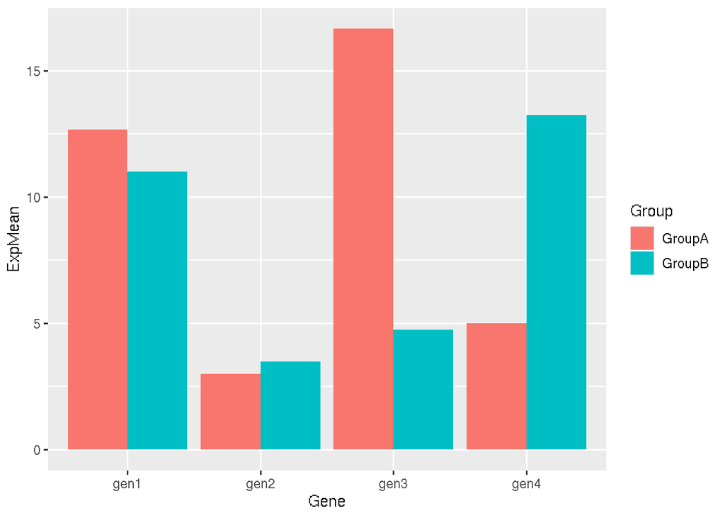

```r
# Plot
p1<-ggplot2::ggplot(meansDf_l, aes(x = Gene, y = ExpMean)) +
  geom_col(aes(fill = Group), position = "dodge")
p1
```

Sin embargo, si me fijo bien en la tabla, algunas muestras parecen tener muchas mas reads totales que otras

```r
SeqDepth <- apply(ExpMatriz, 2, sum)
ExpDf<-rbind(ExpDf, SeqDepth)
rownames(ExpDf)[5]<- "SeqDepth"
ExpDf
```

```
##          samp1.A samp2.A samp3.A samp1.B samp2.B samp3.B
## gen1           9      27       2       1      36       5
## gen2           1       3       5       1       7       1
## gen3          10      30      10       3       3       3
## gen4           3       9       3      10      30      10
## SeqDepth      23      69      20      15      76      19
```

Esto puede pasar y es normal, ya que hay muestras que pueden secuenciarse mas que otras por razones tecnicas, no biologicas.  
Pero entonces los valores con los hicimos las comparaciones no estaban teniendo en cuenta esta pequena diferencia.  
Que pasa si ahora relativizamos todos los valores a la profundidad de secuenciacion de cada muestra?

```r
ExpMatriz_n<- apply(ExpMatriz, 1, function(.x) {.x/SeqDepth}) %>% t()
ExpMatriz_n
```

```
##         samp1.A    samp2.A samp3.A    samp1.B    samp2.B    samp3.B
## gen1 0.39130435 0.39130435    0.10 0.06666667 0.47368421 0.26315789
## gen2 0.04347826 0.04347826    0.25 0.06666667 0.09210526 0.05263158
## gen3 0.43478261 0.43478261    0.50 0.20000000 0.03947368 0.15789474
## gen4 0.13043478 0.13043478    0.15 0.66666667 0.39473684 0.52631579
```

```r
round(ExpMatriz_n, 2)
```

```
##      samp1.A samp2.A samp3.A samp1.B samp2.B samp3.B
## gen1    0.39    0.39    0.10    0.07    0.47    0.26
## gen2    0.04    0.04    0.25    0.07    0.09    0.05
## gen3    0.43    0.43    0.50    0.20    0.04    0.16
## gen4    0.13    0.13    0.15    0.67    0.39    0.53
```

Y si ahora grafico estos resultados

```r
# Mean of group A
GroupA <- apply(ExpMatriz_n[, 1:3], 1, mean)
# Mean of group b
GroupB <- apply(ExpMatriz_n[, 3:4], 1, mean)
# Df of means
meansDf <- data.frame(GroupA, GroupB)
rownames(meansDf) <- c("gen1", "gen2", "gen3", "gen4")
meansDf
```

```
##         GroupA     GroupB
## gen1 0.2942029 0.08333333
## gen2 0.1123188 0.15833333
## gen3 0.4565217 0.35000000
## gen4 0.1369565 0.40833333
```

```r
meansDf$Gene <- rownames(meansDf)
meansDf
```

```
##         GroupA     GroupB Gene
## gen1 0.2942029 0.08333333 gen1
## gen2 0.1123188 0.15833333 gen2
## gen3 0.4565217 0.35000000 gen3
## gen4 0.1369565 0.40833333 gen4
```

```r
# pivot_longer to plot
meansDf_l <- tidyr::pivot_longer(meansDf, cols = c(GroupA, GroupB), names_to = "Group")
names(meansDf_l)[3] <- "ExpMean"
meansDf_l
```

```
## # A tibble: 8 × 3
##   Gene  Group  ExpMean
##   <chr> <chr>    <dbl>
## 1 gen1  GroupA  0.294
## 2 gen1  GroupB  0.0833
## 3 gen2  GroupA  0.112
## 4 gen2  GroupB  0.158
## 5 gen3  GroupA  0.457
## 6 gen3  GroupB  0.35
## 7 gen4  GroupA  0.137
## 8 gen4  GroupB  0.408
```

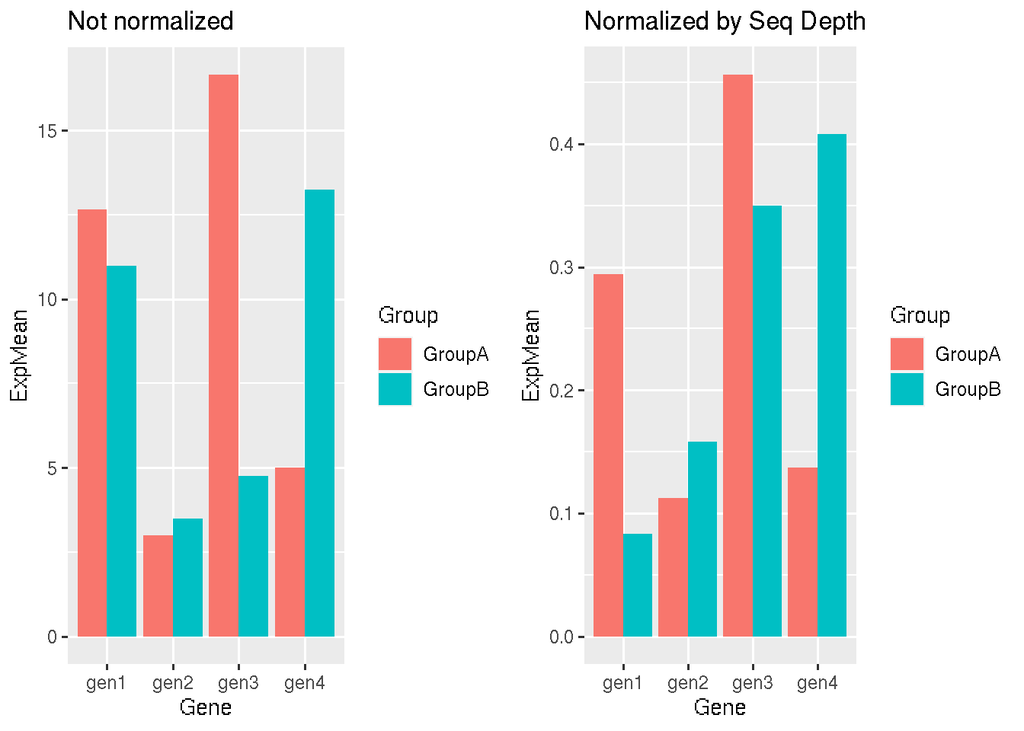

```r
# Plot
p2<-ggplot2::ggplot(meansDf_l, aes(x = Gene, y = ExpMean)) +
  geom_col(aes(fill = Group), position = "dodge") +
  ggtitle("Normalized by Seq Depth")
p1<- p1 + ggtitle("Not normalized")
grid.arrange(p1, p2, nrow = 1)
```

## Usando un data-set de referencia

Ahora probemos los mismo (y algunas cosas mas) usando un data set real:

```r
# Importo la matriz de expresion con los datos crudos:
# Los datos provienen de aca: https://www.ncbi.nlm.nih.gov/geo/query/acc.cgi?acc=GSE114918
# Son datos en donde comparan dos regiones del cerebro con neuronas dopaminergicas con distinta sensibilidad a la neurodegeneracion en la enfermedad de parkinson
RealMatrix <- read_tsv("GSE114918_GEO_COUNTS_LCMseq_humanPK_SNc_VTA.txt")
# Exploremos un poco la matriz:
class(RealMatrix)
```

```
## [1] "spec_tbl_df" "tbl_df"      "tbl"         "data.frame"
```

```r
head(RealMatrix)
```

```
## # A tibble: 6 × 10
##   X         PD_3_VTA PD_4_SNc PD_5_SNc PD_4_VTA PD_2_SNc PD_5_VTA PD_3_SNc PD_1_SNc
##   <chr>        <dbl>    <dbl>    <dbl>    <dbl>    <dbl>    <dbl>    <dbl>    <dbl>
## 1 LEF1             0        0        0        0        0        0        1        0
## 2 FOXJ2           13        1       18        0        7        0       12       50
## 3 MIR3123          0        0        0        0        0        0        0        0
## 4 ZNF654          40        3       17        4       68        0       17       54
## 5 TAL1             0        0        0        0        0        0        0        0
## 6 LOC728323        0        0        0        0        0        0        0        0
## # … with 1 more variable: PD_1_VTA <dbl>
```

```r
names(RealMatrix)
```

```
##  [1] "X"        "PD_3_VTA" "PD_4_SNc" "PD_5_SNc" "PD_4_VTA" "PD_2_SNc"
##  [7] "PD_5_VTA" "PD_3_SNc" "PD_1_SNc" "PD_1_VTA"
```

```r
# Renombro la primer columna
names(RealMatrix)[1] <- "Trsc"
class(RealMatrix$Trsc)
```

```
## [1] "character"
```

```r
class(RealMatrix$PD_3_VTA)
```

```
## [1] "numeric"
```

```r
#Cuantas muestras tengo para SNc?
dplyr::select(RealMatrix, ends_with("SNc")) %>%
  dim()
```

```
## [1] 26274     5
```

```r
#Cuantas muestras tengo para VTA?
dplyr::select(RealMatrix, ends_with("VTA")) %>%
  dim()
```

```
## [1] 26274     4
```

```r
# Genero ahora lo mismo pero como si fuera una matrix ordenada
# escribo en un vector el nombre de las muestras en el orden en el quiero
samples <- c("PD_1_SNc", "PD_2_SNc", "PD_3_SNc", "PD_4_SNc", "PD_5_SNc", "PD_1_VTA", "PD_3_VTA", "PD_4_VTA", "PD_5_VTA")
# Voy a necesitar tener los nombres de los transcriptos a mano, asi qu los pongo en un nuevo vector
TrscNames <- RealMatrix$Trsc
# Transformo el df en matriz. OJo, tengo que omitir la columna de los nombres porque en unamatriz todos los valores son de la misma clase.
RealMatrix <- as.matrix(RealMatrix[,-1])
class(RealMatrix)
```

```
## [1] "matrix"
```

```r
# Reordeno la matriz segun los nombres de las columnas
RealMatrix <- RealMatrix[, samples]
# Agrego nombres de las filas
rownames(RealMatrix) <- TrscNames
# Exploro la matrix
RealMatrix[1:4, 1:6]
```

```
##         PD_1_SNc PD_2_SNc PD_3_SNc PD_4_SNc PD_5_SNc PD_1_VTA
## LEF1           0        0        1        0        0        0
## FOXJ2         50        7       12        1       18        0
## MIR3123        0        0        0        0        0        0
## ZNF654        54       68       17        3       17        6
```

Antes que bada, nos vamos a sacar de encima los genes con counts = 0 en tods las condiciones

```r
total_counts <- apply(RealMatrix, 1, sum)
RealMatrix<-RealMatrix[total_counts>0,]
```

#### Normalizo por el seq Depth ( = library Size):

```r
SeqDepth <- apply(RealMatrix, 2, sum)
RealMatrix_n <- apply(RealMatrix, 1, function(x) x/SeqDepth) %>% t()
head(RealMatrix_n)
```

```
##            PD_1_SNc     PD_2_SNc     PD_3_SNc     PD_4_SNc     PD_5_SNc
## LEF1   0.000000e+00 0.000000e+00 2.430228e-06 0.000000e+00 0.000000e+00
## FOXJ2  1.133150e-04 1.040046e-05 2.916274e-05 6.381539e-06 2.432331e-05
## ZNF654 1.223802e-04 1.010331e-04 4.131388e-05 1.914462e-05 2.297201e-05
## ZMYM2  1.541083e-04 4.650492e-04 8.019753e-05 4.020370e-04 2.797180e-04
## DCAF6  9.065197e-06 9.806150e-05 7.776730e-05 2.807877e-04 4.594402e-05
## PDP1   7.705417e-05 8.468948e-05 3.402319e-05 0.000000e+00 5.134920e-05
##            PD_1_VTA     PD_3_VTA     PD_4_VTA     PD_5_VTA
## LEF1   0.000000e+00 0.000000e+00 0.000000e+00 0.000000e+00
## FOXJ2  0.000000e+00 1.123091e-05 0.000000e+00 0.000000e+00
## ZNF654 9.167976e-06 3.455664e-05 1.288701e-05 0.000000e+00
## ZMYM2  1.084877e-04 2.868201e-04 2.287445e-04 2.059423e-04
## DCAF6  4.583988e-05 1.036699e-05 6.443507e-05 5.933931e-05
## PDP1   1.527996e-04 1.036699e-04 6.443507e-06 8.726369e-05
```

Como vemos, estos valores son muuy chicos y poco interpretables/manajables.  
Probablemente estaria bueno llevarlos a una escala un poco mas razonable (y eso es lo que vamos a hacer en el siguiente paso, vamos multiplicar estos valores por numeros grandes)  
Que tan grandes? Bueno, dependiendo el oorden de los valores por los cuales normalizamos

```r
# SeqDepth -> aprox en el orden del 1000000
# 1 millon
`1M` <- 1000000 # o 10^6
# Mas adelante tendremos en cuenta la longuitud del transcripto
# TrscLength -> aprox en el orden de los 1000
# 1 Kilo
`1K` <- 1000 # o 10^6
```